# chương 3 trich tu bo hoang oppa

**Câu 13:** Một vòng dây được đặt trong từ trường có từ thông vòng dây biến thiên $\mathrm{\Delta}\Phi$ trong khoảng thời gian $\mathrm{\Delta}t$. Biểu thức tính suất điện động cảm ứng trong vòng dây là

**A.** $e_{c} = \frac{\mathrm{\Delta}\Phi}{\mathrm{\Delta}t}.$

**B. #** $e_{c} = - \frac{\mathrm{\Delta}\Phi}{\mathrm{\Delta}t}.$

**C.** $e_{c} = \frac{\mathrm{\Delta}\Phi}{2.\mathrm{\Delta}t}.$

**D.** $e_{c} = - \frac{2\mathrm{\Delta}\Phi}{\mathrm{\Delta}t}.$

**Câu 14:** Điện áp xoay chiều $u = 15\cos\left( 100\pi t + \frac{\pi}{2} \right)\ V$ (đơn vị của thời gian t là s) có tần số là

**A. #** 50 Hz.

**B.** 100 Hz.

**C.** 100π Hz.

**D.** 50π Hz.

**Câu 15:** Một đoạn dây dẫn thẳng mang dòng điện được đặt trong vùng từ trường đều sao cho phương của đoạn dây vuông góc với các đường sức từ. Khi đó, lực từ tác dụng lên đoạn dây dẫn có phương

**A.** # vuông góc với đoạn dây dẫn và vuông góc với đường sức từ.

**B.** vuông góc với đoạn dây dẫn và song song với đường sức từ.

**C.** dọc theo dây dẫn và song song với đường sức từ.

**D.** dọc theo dây dẫn và vuông góc với đường sức từ.

**Câu 12 (Đ/S).** Hình vẽ bên dưới mô tả một đoạn dây thẳng mang dòng điện, có chiều dài L, mang dòng điện có cường độ *i*, đặt trong từ trường đều có vector cảm ứng từ $\overrightarrow{B}$ (độ lớn $B$). Vector $\overrightarrow{L}$ là vector chiều dài của đoạn dây, hướng theo chiều dòng điện. Góc hợp bởi ${\overrightarrow{L}}_{}$ và ${\overrightarrow{B}}_{}$ là $\phi$ Lực từ tác dúng lên đoạn dây là ${\overrightarrow{F}}_{B}.$

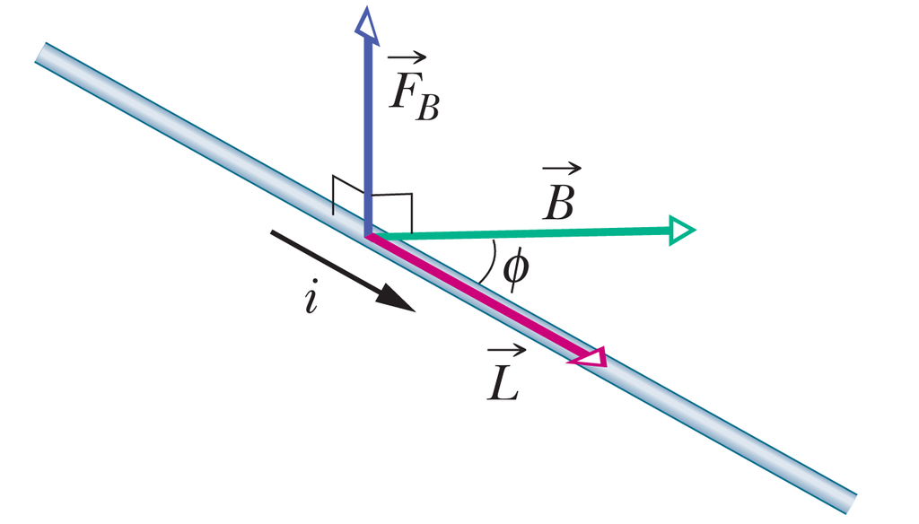

**a) #** Độ lớn của vector lực từ là $\left| {\overrightarrow{F}}_{B} \right| = iBL\sin\phi.$

**b) #** Khi $\phi$ tăng từ $0{^\circ}$ đến $360{^\circ},$ giá trị của $\phi$ mà tại đó lực từ đổi chiều là $\phi = 0{^\circ},\ \phi = 180{^\circ}.$

c) # Dùng qui tắc xòe tay trái để xác định được chiều của lực từ.

d) Lực từ có xu hướng kéo dây đi xuống

**Câu 10:** Một học sinh thực hiện thí nghiệm để xác định độ lớn lực từ giữa hai nam châm như hình vẽ: đặt nam châm 1 trên cân thì số chỉ của cân là 80,0g; sau đó đặt nam châm 2 phía trên nam châm 1 thì số chỉ của cân là 83,1g. Gia tốc trong trường tại nơi làm thí nghiệm là 9,8 m/s<sup>2</sup>. Thí nghiệm này cho biết

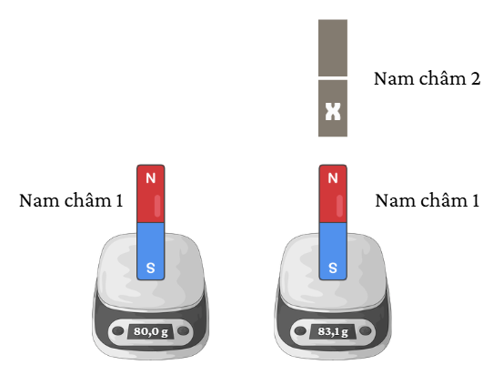

**A.** # Độ lớn lực từ tương tác giữa nam châm là 30,38 mN.

**B.** Cực từ X của nam châm 2 là cực nam.

**C.** Khối lượng của nam châm 2 là 3,1 g.

**D.** Lực từ tương tác giữa hai nam châm là lực hút.

**[HD]** *Ta thấy khi đưa nam châm 2 lại gần nam châm 1, giá trị trên cân tăng lên chứng tỏ tương tác giữa hai nam châm là tương tác đẩy và cực từ X của nam châm 2 là cực Bắc (N). Độ lớn của lực từ này:* $F_{t} = \mathrm{\Delta}m.g = (83,1 - 80).10^{- 3} \bullet 9,8 = 0,03038\ N = 30,38\ mN.$

**Câu 3.** Đâu **không** phải là một thiết bị hoạt động dựa trên hiện tượng cảm ứng điện từ?

**A.** # Kim la bàn.

**B**. Máy biến áp.

**C.** Đàn guitar điện.

**D.** Máy phát điện.

**Câu 7.** Cho một vòng dây mềm, phẳng, nằm trong mặt phẳng trang giấy, mang dòng điện như hình bên. Vòng dây được đặt trong từ trường đều có cảm ứng từ hướng ra ngoài mặt phẳng giấy. Dưới tác dụng của lực từ, vòng dây

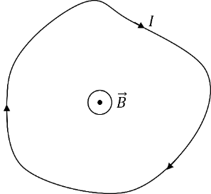

**A.** căng ra.

**B**. # chum lại.

**C.** tịnh tiến dọc theo vector cảm ứng từ.

**D.** tịnh tiến ngược chiều vector cảm ứng từ.

**Câu 11.** Đâu **không** phải một ưu điểm của dòng điện xoay chiều so với dòng điện không đổi?

**A.** Dòng điện xoay chiều có thể được tăng áp để giảm hao phí khi truyền tải đi xa nhờ máy biến áp.

**B**. Dòng điện xoay chiều dễ tạo ra nhờ tua bin hoạt động dựa trên hiện tượng cảm ứng điện từ.

**C.** # Dòng điện xoay chiều có thể được tích hợp trong các thiết bị tiện ích nhỏ gọn như sạc dự phòng, pin.

**D.** Dòng điện xoay chiều có thể được tạo ra từ công cơ học và một số bộ phận như nam châm, cuộn dây.

**Câu 15.** Đâu là một cách để có thể sinh ra suất điện động cảm ứng trong một vòng dây được đặt trong từ trường?

**A.** tịnh tiến khung dây trong một từ trường đều.

**B**. # tịnh tiến khung dây trong một từ trường không đều.

**C.** quay khung dây trong từ trường đều quanh trục trùng với đường sức từ.

**D.** để khung dây nằm yên trong từ trường không đều.

**Câu 17. *:*** Cho bốn vật là A, B, C, D có bề ngoài và trọng lượng hoàn toàn giống nhau. Trong bốn vật đó đó có hai thỏi nam châm vĩnh cửu, hai thỏi sắt. Bạn Bình thiết kế một thí nghiệm như sau. Bạn lần lượt thả các vật qua một ống rỗng bằng đồng theo phương thẳng đứng từ cùng một độ cao so với mặt bàn. Ống đồng được giữ cố định. Bạn thu được kết quả về thời gian rơi đến khi chạm bàn của các vật lần lượt là $t_{A} = 2\text{,44s; }t_{B} = \text{0,51s,}$ $t_{C} = \text{3,24s; }t_{D} = \text{0,50s.}$ Kết luận đúng là

**A.** A và C là sắt.

**B**. # B và D là sắt.

**C.** A và B là sắt.

**D.** A và D là sắt.

[HD]  
vì nam châm rơi trong ống đồng sẽ bị chậm lại do xuất hiện dòng điện cảm ứng, chống lại chuyển động rơi của nam châm. Nên vật A,C có thời gian rơi chậm hơn sẽ là nam châm, còn B, D có thời gian rơi gần giống nhau nên ko phải nam châm mà là sắt.

**Câu 18. *:*** Cho bốn vật là A, B, C, D có bề ngoài và trọng lượng hoàn toàn giống nhau. Trong bốn vật đó đó có hai thỏi nam châm vĩnh cửu, hai thỏi sắt. Bạn Bình thiết kế một thí nghiệm như sau. Bạn lần lượt thả các vật qua một ống rỗng bằng đồng theo phương thẳng đứng từ cùng một độ cao so với mặt bàn. Ống đồng được giữ cố định. Bạn thu được kết quả về thời gian rơi đến khi chạm bàn của các vật lần lượt là $t_{A} = 2\text{,44s; }t_{B} = \text{0,51s,}$ $t_{C} = \text{3,24s; }t_{D} = \text{0,50s. }$Cơ sở vật lý để đưa ra kết luận ở câu trên là

**A.** # Hiện tượng cảm ứng điện từ và định luật Lenz.

**B**. Tương tác giữa nam châm và từ trường Trái Đất.

**C.** Từ tính của đồng giống như sắt.

**D.** Đồng không tương tác với nam châm.

[HD]  
Khi nam châm rơi trong ống đồng, từ thông nó gây ra trên từng phần của ống đồng biến thiên, sinh ra suất điện động cảm ứng. Vì đồng là vật dẫn nên xuất hiện dòng điện cảm ứng. Dòng điện cảm ứng này sinh ra từ trường cảm ứng có chiều chống lại nguyên nhân biến thiên từ thông ban đầu, chính là sự rơi của nam châm. Vì vậy, lực từ mà từ trường cảm ứng này tác dụng lên nam châm sẽ cản sự rơi của nam châm lại. Do đó, thời gian rơi của các nam châm dài hơn so với sự rơi tự do bình thường.

**Câu 4 (Đ/S).** Khi một điện tích bay vào trong từ trường đều trong mặt phẳng vuông góc với đường sức từ, lực từ sẽ khiến chúng chuyển động tròn đều. Tùy vào dấu của điện tích, hướng chuyển động của hạt là khác nhau. Một ví dụ được minh họa trong Hình 1.

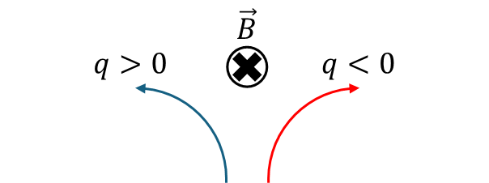

Cho biết bán kính của quỹ đạo tròn của một hạt mang điện tích $q,$ khối lượng $m,$ tốc độ $v,$ trong từ trường đều có độ lớn cảm ứng từ $B$ là $r = \frac{mv}{|q|B}.$  
Để quan sát quỹ đạo của các hạt nhỏ như electron, các nhà vật lý đã sử dụng một thiết bị gọi là buồng mây. Khi một hạt bay qua buồng mây, các nhà vật lý có thể quan sát được quỹ đạo của chúng. Hình 2 (bên trái) là ảnh chụp quỹ đạo của một hạt (vệt cong màu đen) khi bay vào buồng mây và xuyên qua tấm chì mỏng ở giữa. Tấm chì có hai mặt là (1) và (2) như trong hình. Từ trường có chiều như hình vẽ. Điện trường bằng không. Biết rằng vệt cong màu đen là hai cung tròn liên tiếp nhau, có bán kính khác nhau. Hình bên phải (nét đứt) là hai phần cung tròn chứa hai phần quỹ đạo của hạt trước và sau khi bay qua tấm chì.

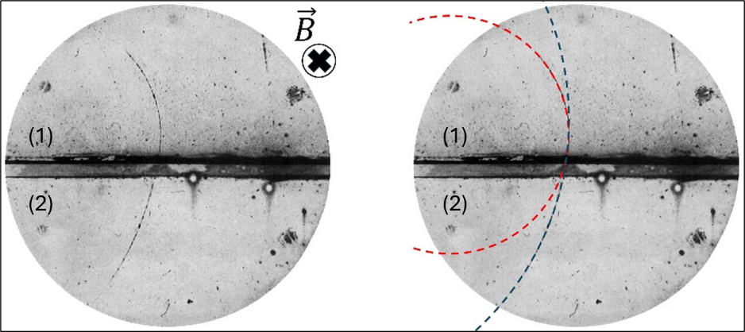

*Hình 2. Ảnh chụp quỹ đạo của một hạt quan sát được bởi buồng mây*.

a) # Nếu xác định được tốc độ của hạt, bán kính quỹ đạo và cảm ứng từ, ta có thể suy ra thương số giữa khối lượng và điện tích của hạt.

b) # Bán kính quỹ đạo tròn của hạt tỉ lệ thuận với độ lớn động lượng của hạt đó.

c) Khi quan sát quỹ đạo của hạt trong Hình 2, người ta có thể kết luận hạt này đã bay qua tấm chì theo hướng từ mặt (1) sang mặt (2).

d) # Đây là một hạt mang điện tích dương.

[HD]  
**a) ĐÚNG** *Theo công thức* $r = \frac{mv}{|q|B},$ *nếu xác định được tốc độ của hạt, bán kính quỹ đạo và cảm ứng từ, ta có thể suy ra thương số giữa khối lượng và điện tích của hạ*  
**b) ĐÚNG** *Theo công thức* $r = \frac{mv}{|q|B},$ *động lượng* $p = mv$ *tỉ lệ thuận với bán kĩnh quỹ đạo*  
**c) SAI** *Trong Hình 2, ta thấy bán kính quỹ đạo phía trên tấm chì (mặt (1)) nhỏ hơn phía dưới (mặt (2)), suy ra động lượng ở mặt (1) tấm chì nhỏ hơn. Suy ra hạt bay vào từ mặt (2) xuyên qua tấm chì và bị mất đi một phần động lượng.*  
**d) ĐÚNG** *Vì đã biết hạt bay vào từ mặt (2), dựa vào Hình 1, suy ra hạt này mang điện tích dương.*

**Câu 9.** Phát biểu nào sau đây nói lên tính chất khác biệt của nam châm điện so với nam châm vĩnh cửu?

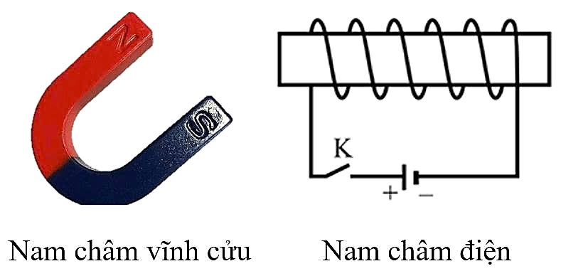

**A.** Nam châm điện có cực từ Bắc và cực từ Nam.

**B.** Nam châm điện có thể hút các vật làm bằng vật liệu từ.

**C.** # Có thể bật hoặc tắt từ trường của nam châm điện.

**D.** Không thể đảo ngược được cực từ của nam châm điện.

**câu 12 (Đ/S):** Một đoạn dây dẫn thẳng MO dài 12 cm được gấp tại trung điểm N thành hai đoạn MN và NO nằm trong mặt phẳng hình vẽ. Dây dẫn được đặt vào vùng có từ trường đều, các vector cảm ứng từ có phương, chiều như hình vẽ và có độ lớn bằng 0,01 T. Dòng điện không đổi chạy trong dây dẫn MO có cường độ 2 A. Biết α = 40°.

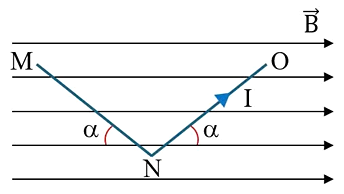

**a) #** Lực từ tác dụng lên đoạn dây dẫn MN có độ lớn bằng 7,71.10<sup>−4</sup> N.

b) Lực từ tác dụng lên dây MN lớn hơn lực từ tác dụng lên dây NO.

c) Lực từ tác dụng lên dây MN cùng chiều với lực từ tác dụng lên dây NO.

d) # lực từ tác dụng lên 2 dây làm dây bị quay

**Câu 3 (Đ/S).** Một khung dây dẫn kín gồm 500 vòng, mỗi vòng có diện tích là 80 dm<sup>2</sup>. Khung dây dẫn được đặt trong một từ trường đều sao cho vector cảm ứng từ hợp với vector pháp tuyến của mặt phẳng khung dây một góc 60°. Độ lớn cảm ứng từ biến thiên theo thời gian như đồ thị trong hình bên dưới.

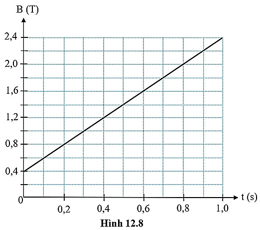

a) # Tại thời điểm ban đầu t = 0 s, từ thông xuyên qua diện tích mỗi vòng dây có độ lớn bằng 0,16 Wb.

b) # Suất điện động cảm ứng xuất hiện trong khung dây dẫn trong 0,1 giây đầu có độ lớn bằng 400V

c) # Tốc độ biến thiên cảm ứng từ qua khung dây là 2 T/s

d) # Độ lớn suất điện động cảm ứng trong khung dây tỉ lệ thuận tới tốc độ biến thiên của cảm ứng từ trong khung dây.

**[HD]** *Tại thời điểm ban đầu t = 0 s, từ thông xuyên qua diện tích mỗi vòng dây có độ lớn bằng:* $\Phi = BS\cos\left( \overrightarrow{n};\overrightarrow{B} \right) = 0,4.80.10^{- 2}.\cos{60{^\circ}} = 0,16$ *Wb.*

**Câu 4.** Cảm ứng từ có đơn vị trong hệ SI là T (tesla). Đơn vị này được biểu diễn theo các đơn vị cơ bản trong hệ SI như thế nào?

**A.** $\frac{\text{kg}}{\text{m.A.}\text{s}^{2}}.$

**B.** $\frac{\text{kg.m}}{\text{A.}\text{s}^{2}}.$

**C.** $\frac{1}{\text{kg.A.}\text{s}^{2}}.$

**D.** # $\frac{\text{kg}}{\text{A.}\text{s}^{2}}.$

[HD] Theo các đơn vị cơ bản, $\text{T=}\frac{N}{\text{A.m}} = \frac{\text{kg.m}}{s^{2}\text{.A.m}} = \frac{\text{kg}}{\text{A.}\text{s}^{2}}.$

**Câu 6.** Cho một dòng điện xoay chiều có biểu thức $i = 2\cos(100\pi t),$ trong đó i đo bằng A, t đo bằng s. Tần số của dòng điện là

**A.** 5 Hz.

**B.** 100 Hz.

**C.** # 50 Hz.

**D.** 10 Hz.

**Câu 7.** Cho một dòng điện xoay chiều có biểu thức $i = 2\cos(100\pi t),$ Khi cho dòng điện trên chạy qua một điện trở có giá trị *R* không đổi, công suất tỏa nhiệt trung bình của dòng điện này bằng với công suất tỏa nhiệt của một dòng điện không đổi có cường độ bao nhiêu nếu đặt lên cùng điện trở đó?

**A.** $2\sqrt{2}$ A.

**B.** $2$A.

**C. #** $\sqrt{2}$ A.

**D.** 4 A.

**Câu 16.** Đâu **không** phải là một ứng dụng của hiện tượng cảm ứng điện từ?

**A.** # Pin, acquy.

**B.** Máy phát điện.

**C.** Đàn guitar điện.

**D.** Sạc không dây.

**Câu 17.** Một electron được gia tốc từ trạng thái nghỉ tại điểm A đến điểm B có điện thế cao 1 V thì động năng của electron là

**A.** 1 MeV.

**B.** # 1 eV.

**C.** 10 eV.

**D.** 1 keV.

**Câu 2 (Đ/S).** Một thanh đồng được đặt lên hai giá đỡ song song, dẫn điện như hình. Bỏ qua ma sát giữa thanh đồng và giá đỡ. Một nguồn điện *G* được gắn vào mạch để duy trì dòng điện không đổi qua mạch. Chiều của dòng điện được vẽ như trong hình, cường độ dòng điện là $i = 200\text{ mA}.$ Thanh đồng có khối lượng $m = \text{60 g,}$ hai giá đỡ cách nhau một khoảng $d = \text{15 cm}.$ Hệ được đặt trong vùng từ trường đều có vector cảm ứng từ vuông góc với mặt phẳng chứa thanh đồng và giá đỡ, hướng như trong hình. Độ lớn của cảm ứng từ là $B = \text{0,95 T}.$

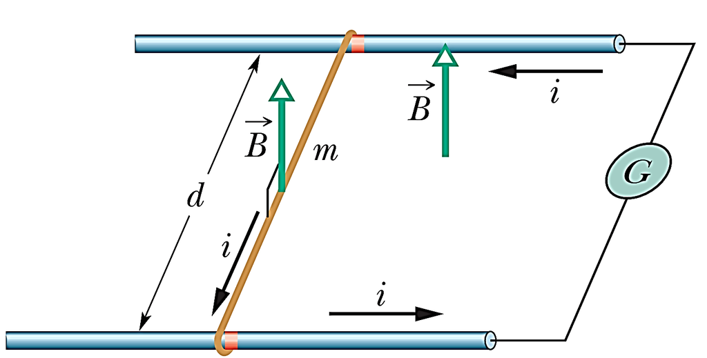

a) Thanh đồng chịu tác dụng của lực từ hướng về phía nguồn điện G.

b) # Với dòng điện trong đề bài, độ lớn của lực từ tác dụng lên thanh đồng là 28,5 mN.

c) # Khi thanh đồng chuyển động, trong mạch xuất hiện hiện tượng cảm ứng điện từ.

d) Khi ngắt nguồn điện, thanh đồng tiếp tục chuyển động thẳng đều.

[HD]  
**a) SAI** *Áp dụng quy tắc bàn tay trái, thanh đồng chịu tác dụng của lực từ hướng sang trái (ra xa nguồn điện G)*  
**b) ĐÚNG** *Độ lớn lực từ tác dụng lên thanh đồng là* $F = iBd = 200 \times 10^{- 3} \times \text{0,95} \times \text{0,15} = \text{28,5 mN}.$  
**c) ĐÚNG** *Vì diện tích mạch kín thay đổi trong vùng có từ trường đều vuông góc với mặt phẳng chứa mạch, từ thông thay đổi và do đó có hiện tượng cảm ứng điện từ.*  
**d) SAI** *Khi ngắt dòng điện, do có quán tính nên thanh tiếp tục chuyển động. Vì thanh tiếp tục chuyển động nên vẫn còn suất điện động cảm ứng, vì vậy trong thanh vẫn còn dòng điện (cảm ứng). Theo định luật Lenz, dòng điện này có chiều sao cho lực từ tác dụng lên thanh cản trở chuyển động của thanh, làm cho nó chuyển động chậm dần.*

**Câu 1.** Bếp điện từ là thiết bị nấu ăn, trong đó cuộn dây đặt dưới mặt bếp được cấp dòng điện xoay chiều, tạo ra từ trường biến thiên. Khi đặt nồi có đáy bằng kim loại thích hợp lên bếp, nồi nóng lên nhanh chóng dù mặt bếp không trực tiếp phát nhiệt. Bếp điện từ hoạt động chủ yếu dựa trên hiện tượng nào sau đây?

[figure not shown]

**A.** Hiện tượng bức xạ nhiệt.

**B.** Hiện tượng dẫn nhiệt.

**C. #** Hiện tượng cảm ứng điện từ.

**D.** Hiện tượng phát xạ electron.

**Câu 9.** Khi nói về vector cảm ứng từ $\overrightarrow{B}$, phát biểu nào sau đây là **sai**?

**A.** Vector cảm ứng từ $\overrightarrow{B}$ tại một điểm trong từ trường có phương trùng với tiếp tuyến của đường sức từ tại điểm đó.

**B.** Chiều của vector cảm ứng từ $\overrightarrow{B}$ tại một điểm trong từ trường cùng chiều với chiều của đường sức từ đi qua điểm đó.

**C.** Độ lớn của vector cảm ứng từ $\overrightarrow{B}$ tại một điểm trong từ trường đặc trưng cho độ mạnh yếu của từ trường tại điểm đó.

**D.** # Vector cảm ứng từ $\overrightarrow{B}$ tại một điểm trong từ trường có phương trùng với phương của kim nam châm và có chiều là chiều từ cực Bắc (N) sang cực Nam (S) của kim nam châm đặt tại điểm đó.

**[HD]** *Phát biểu D sai. Vì vector cảm ứng từ* $\overrightarrow{B}$ *tại một điểm trong từ trường có phương trùng với phương của kim nam châm và có chiều là chiều từ cực Nam (S) sang cực Bắc (N) của kim nam châm đặt tại điểm đó.*

**Câu 10.** Sóng điện từ là sóng

**A.** dọc và không truyền được chân không.

**B. #** ngang và truyền được trong chân không.

**C.** ngang và không truyền được trong chân không.

**D.** dọc và truyền được trong chân không.

**[HD]** *Sóng điện từ là sóng ngang và truyền được trong chân không.*

**Câu 11.** Một dây dẫn được uốn thành một khung dây có dạng tam giác vuông tại A, với AM = 3 cm có dòng điện không đổi với cường độ 5 A chạy qua. Đặt khung dây vào trong từ trường đều sao cho mặt phẳng khung dây song song với các đường sức từ và các vector cảm ứng từ song song với cạnh AN và có chiều như hình vẽ bên dưới. Biết rằng độ lớn cảm ứng từ là 3 mT và giữ khung dây cố định.

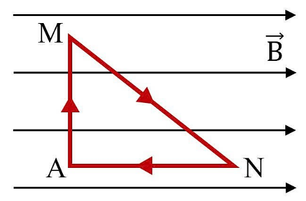

Lực từ tác dụng lên đoạn dây dẫn MN có độ lớn bằng bao nhiêu?

**A.** 0,6 mN.

**B.** 45 mN.

**C.** # 0,45 mN.

**D.** 60 mN.

**[HD]** *Lực từ tác dụng lên đoạn dây dẫn MN có độ lớn bằng* $F = B.I\mathcal{.l.}\sin\alpha = B.I.MN.\sin\widehat{MNA} = B.I.AM = 3.10^{- 3}.5.3.10^{- 2} = 0,45$ *mN.*

**Câu 12.** Một dây dẫn được uốn thành một khung dây có dạng tam giác vuông tại A, với AM = 3 cm có dòng điện không đổi với cường độ 5 A chạy qua. Đặt khung dây vào trong từ trường đều sao cho mặt phẳng khung dây song song với các đường sức từ và các vector cảm ứng từ song song với cạnh AN và có chiều như hình vẽ bên dưới. Biết rằng độ lớn cảm ứng từ là 3 mT và giữ khung dây cố định.

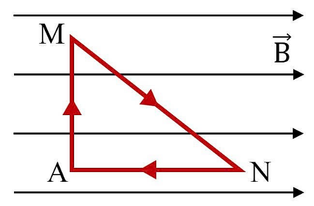

Từ thông xuyên qua diện tích S (m<sup>2</sup>) của khung dây dẫn có độ lớn bằng

**A.** 3S (Wb).

**B.** 3.10<sup>−3</sup>S (Wb).

**C. #** 0 (Wb).

**D.** 0,9S (Wb).

[HD] *Từ thông xuyên qua diện tích S (m<sup>2</sup>) của khung dây dẫn có độ lớn bằng:* $\Phi = NBS.\cos\left( \overrightarrow{n};\overrightarrow{B} \right) = 1.3.10^{- 3}.S.\cos{90{^\circ}} = 0$ *Wb.*

**Câu 13.** Một khung dây dẫn quay đều quanh trục ∆ với tốc độ 120 vòng/phút trong một từ trường đều có các đường sức từ vuông góc với trục ∆. Tại một thời điểm nào đó từ thông qua khung dây là 3 Wb thì suất điện động cảm ứng trong khung dây bằng 16π V. Từ thông cực đại qua khung dây dẫn đó là

**A.** 6 Wb.

**B.** # 5 Wb.

**C.** 5π Wb.

**D.** 6π Wb.

**[HD]** *Ta có:* $\omega = 2\pi.f = 2\pi.\frac{120}{60} = 4\pi$ rad/s.  
Do từ thông và suất điện động cảm ứng xuất hiện trong khung dây dẫn biến thiên điều hòa theo thời gian và vuông pha nhau nên ta có: $\left( \frac{\Phi}{\Phi_{0}} \right)^{2} + \left( \frac{e_{c}}{E_{0}} \right)^{2} = 1$ *⇔* $\left( \frac{\Phi}{\Phi_{0}} \right)^{2} + \left( \frac{e_{c}}{\omega.\Phi_{0}} \right)^{2} = 1$ *⇒* $\Phi_{0} = \sqrt{\Phi^{2} + \left( \frac{e_{c}}{\omega} \right)^{2}} = \sqrt{3^{2} + \left( \frac{16\pi}{4\pi} \right)^{2}} = 5$ *Wb.*

**Câu 14.** Một vòng dây dẫn phẳng hình vuông có cạnh dài 20 cm được đặt trong một từ truờng đều, mặt phẳng khung dây dẫn vuông góc với các đường sức từ. Trong khoảng thời gian 0,2 s, độ lớn cảm ứng từ của từ trường giảm đều từ 1,2 T về 0 T. Suất điện động cảm ứng xuất hiện trong khung dây dẫn trong khoảng thời gian đó có độ lớn là bao nhiêu?

**A.** 2,4 V.

**B.** 240 V.

**C.** # 240 mV.

**D.** 2,4 mV.

**[HD]**

*Suất điện động cảm ứng xuất hiện trong vòng dây dẫn trong 0,2 giây có độ lớn bằng:* $\left| e_{c} \right| = \left| - \frac{\mathrm{\Delta}\Phi}{\mathrm{\Delta}t} \right| = \left| - \frac{N.\mathrm{\Delta}B.S.\cos\left( \overrightarrow{n};\overrightarrow{B} \right)}{\mathrm{\Delta}t} \right| = \left| - \frac{1.(0 - 1,2).\left( 20.10^{- 2} \right)^{2}.\cos{0{^\circ}}}{0,2} \right| = 0,24$ *V = 240 mV.*